# 5003_3.0

W11_G07

2025-09-20

```r
#---2. Data Description---
path <- "./final_decoded.csv"
df <- read.csv(path,
               header = TRUE,
               fileEncoding = "UTF-8",
               na.strings = c("", "NA"))
#head(df)

library(dplyr)
library(tibble)
library(knitr)

n_rows <- nrow(df)
n_cols <- ncol(df)

is_num <- sapply(df, is.numeric)
n_numeric    <- sum(is_num, na.rm = TRUE)
n_non_numeric <- n_cols - n_numeric

summary_tbl <- tibble::tibble(
  Indicator = c(" rows", "columns", "Numeric variable", "Non-numeric variable"),
  number = c(n_rows, n_cols, n_numeric, n_non_numeric)
)

library(dplyr)
library(purrr)
library(tibble)
library(knitr)
num_cols<- names(df)[sapply(df, is.numeric)]
num_profile <- purrr::map_dfr(num_cols, function(cn) {
  s <- df[[cn]]; n <- length(s)
  non_na <- sum(!is.na(s)); miss <- sum(is.na(s))
  miss_rate <- miss / n * 100
  uniq <- dplyr::n_distinct(s, na.rm = TRUE)
  zero_cnt  <- sum(s == 0, na.rm = TRUE)
  zero_rate <- zero_cnt / n * 100
  qs <- quantile(s, probs = c(0, 0.25, 0.5, 0.75, 1),
                 na.rm = TRUE, names = FALSE, type = 7)

  tibble::tibble(
    `Indicator`          = cn,
    `non-missing`        = non_na,
    `Missing values`     = miss,
    `Missing Rate%`      = round(miss_rate, 2),
    `Unique value count` = uniq,
    `zero value`         = zero_cnt,
    `Zero-rate%`         = round(zero_rate, 2),
    `mean`               = mean(s, na.rm = TRUE),
    `Standard deviation` = sd(s, na.rm = TRUE),
    `min` = qs[1], `P25` = qs[2], `median` = qs[3], `P75` = qs[4], `max` = qs[5]
  )
})
num_profile <- num_profile %>%
  mutate(
    across(
      all_of(c("mean", "Standard deviation", "min", "P25", "median", "P75", "max")),
      ~ round(.x, 4)
    )
  ) %>%
  arrange(desc(`Missing Rate%`), `Indicator`)

num_profile_table <- kable(num_profile, align = "lrrrrrrrrrrrrr")


cat_cols <- names(df)[!sapply(df, is.numeric)]
topk <- 3
cat_profile <- map_dfr(cat_cols, function(cn) {
  s <- df[[cn]]
  n <- length(s)
  non_na <- sum(!is.na(s))
  miss   <- sum(is.na(s))
  miss_rate <- miss / n * 100
  uniq <- dplyr::n_distinct(s, na.rm = TRUE)

  vc <- sort(table(as.character(s[!is.na(s)]), useNA = "no"), decreasing = TRUE)
  k  <- min(topk, length(vc))
  top_vals  <- if (k > 0) names(vc)[seq_len(k)] else character(0)
  top_freqs <- if (k > 0) as.integer(vc[seq_len(k)]) else integer(0)

   if (length(top_vals) < topk)  top_vals  <- c(top_vals,  rep(NA_character_, topk - length(top_vals)))
  if (length(top_freqs) < topk) top_freqs <- c(top_freqs, rep(NA_integer_,  topk - length(top_freqs)))

  tibble(
    variable         = cn,
    non_missing      = non_na,
    missing          = miss,
    missing_rate_pct = round(miss_rate, 2),
    unique_count     = uniq,
    top1_value       = top_vals[1],
    top1_count       = top_freqs[1],
    top1_pct         = round(top_freqs[1] * 100 / n, 2),
    top2_value       = top_vals[2],
    top2_count       = top_freqs[2],
    top2_pct         = round(top_freqs[2] * 100 / n, 2),
    top3_value       = top_vals[3],
    top3_count       = top_freqs[3],
    top3_pct         = round(top_freqs[3] * 100 / n, 2)
  )
})

cat_profile <- cat_profile %>% arrange(desc(missing_rate_pct), variable)

cat_profile_table <- kable(cat_profile, align = "lrrrrlrrlrrlrr")

# set Parameters
threshold_mad      <- 7      # robust z threshold; 7 is conservative
min_non_missing    <- 30     # skip columns with too few non-missing values
show_only_ge1pct   <- TRUE   # report only columns with >= 1% outliers

num_cols <- names(df)[sapply(df, is.numeric)]
mad_raw <- function(x) mad(x, na.rm = TRUE, constant = 1)

#---outlier---
# Compute outlier rate per numeric column
outlier_rate_tbl <- map_dfr(num_cols, function(cn) {
  s <- df[[cn]]
  s <- s[!is.na(s)]
  n <- length(s)
  if (n < min_non_missing) {
    return(tibble(
      variable = cn, non_missing = n,
      outlier_count = NA_integer_, outlier_rate_pct = NA_real_,
      median = NA_real_, mad = NA_real_
    ))
  }
  med <- median(s, na.rm = TRUE)
  m   <- mad_raw(s)
  if (is.na(m) || m == 0) {
    return(tibble(
      variable = cn, non_missing = n,
      outlier_count = NA_integer_, outlier_rate_pct = NA_real_,
      median = med, mad = m
    ))
  }
  rz  <- abs(s - med) / m
  cnt <- sum(rz > threshold_mad, na.rm = TRUE)
  tibble(
    variable = cn,
    non_missing = n,
    outlier_count = cnt,
    outlier_rate_pct = round(cnt * 100 / n, 3),
    median = med,
    mad = m
  )
})

outlier_rate_tbl <- outlier_rate_tbl %>%
  arrange(desc(outlier_rate_pct), variable)

if (show_only_ge1pct) {
  outlier_rate_tbl <- outlier_rate_tbl %>%
    filter(!is.na(outlier_rate_pct), outlier_rate_pct >= 1)
}
result_outliers <- outlier_rate_tbl %>%
  select(variable, outlier_rate_pct, outlier_count, non_missing)

outliers_table <- kable(result_outliers, align = "lrrr",
      col.names = c("variable", "outlier_rate_pct", "outlier_count", "non_missing"))

#---High Cardinality---
# Choose categorical columns
cat_cols <- names(df)[sapply(df, function(x) is.character(x) || is.factor(x))]

# Compute unique counts and rates
n <- nrow(df)
hi_card_tbl <- lapply(cat_cols, function(cn) {
  s <- df[[cn]]
  u <- dplyr::n_distinct(s, na.rm = TRUE)
  tibble(
    variable = cn,
    n_unique = u,
    unique_rate_pct = round(u * 100 / max(1, n), 2)
  )
}) |> bind_rows()

# Filter by high-cardinality rule and sort
hi_card_tbl <- hi_card_tbl |>
  filter(n_unique > 100 | unique_rate_pct > 50) |>
  arrange(desc(n_unique), desc(unique_rate_pct), variable)

# Print as a table
hi_card_table <- kable(hi_card_tbl, align = "lrr",
      col.names = c("variable", "n_unique", "unique_rate_pct"))

#---Zero flation---
# Parameters
threshold_pct <- 90  # zero-rate threshold (percentage)

# Select numeric columns
num_cols <- names(df)[sapply(df, is.numeric)]

# Compute zero rate per numeric column
zero_inflated_tbl <- map_dfr(num_cols, function(cn) {
  s <- df[[cn]]
  n_non_missing <- sum(!is.na(s))
  if (n_non_missing == 0) {
    return(tibble(variable = cn, zero_rate_pct = NA_real_))
  }
  zeros <- sum(s == 0, na.rm = TRUE)
  tibble(
    variable = cn,
    zero_rate_pct = round(100 * zeros / n_non_missing, 2)
  )
}) %>%
  filter(!is.na(zero_rate_pct), zero_rate_pct >= threshold_pct) %>%
  arrange(desc(zero_rate_pct), variable)
```

```r
# Print as a table
zero_inflated_table <- kable(zero_inflated_tbl, align = "lr",
      col.names = c("variable", "zero_rate_pct"))

#---Multicolinearlity---
# Parameters
corr_threshold <- 0.95   # |r| threshold

# Select numeric columns
num_cols <- names(df)[sapply(df, is.numeric)]

# Compute correlation matrix
if (length(num_cols) < 2) {
  result_corr <- tibble(
    var1 = character(0), var2 = character(0),
    r = numeric(0), abs_r = numeric(0)
  )
} else {
  cor_mat <- suppressWarnings(
    cor(df[, num_cols, drop = FALSE], use = "pairwise.complete.obs", method = "pearson")
  )
  # Extract upper triangle pairs
  idx <- which(upper.tri(cor_mat), arr.ind = TRUE)
  result_corr <- tibble(
    var1  = rownames(cor_mat)[idx[, 1]],
    var2  = colnames(cor_mat)[idx[, 2]],
    r     = cor_mat[idx],
    abs_r = abs(cor_mat[idx])
  ) %>%
    filter(!is.na(r), abs_r >= corr_threshold) %>%
    arrange(desc(abs_r), var1, var2)
}

# Print as a table
corr_table <- kable(result_corr, align = "llrr",
      col.names = c("var1", "var2", "r", "abs_r"))

#---3.Data Cleaning---
library(readr); library(dplyr); library(tidyr); library(stringr)
library(janitor); library(ggplot2); library(scales); library(purrr)

in_csv  <- "final_decoded.csv"
out_csv <- "final_decoded_clean.csv"

# Use a different variable name to avoid conflict with base R's df function
df <- readr::read_csv(in_csv, show_col_types = FALSE) %>%
  mutate(across(everything(), ~ ifelse(is.character(.x) &
      stringr::str_trim(.x) %in% c("", "Missing", "missing", "N/A", "NA", "n/a"), NA, .x)))

#message(sprintf("Initial dataset: %d rows × %d columns", nrow(df), ncol(df)))

#--3.1 Missing Value---
# Check and clean target variable
if ("STOP_MAINMODE" %in% names(df)) {
  target_missing <- sum(is.na(df$STOP_MAINMODE) | df$STOP_MAINMODE == "")
  df <- df %>% filter(!is.na(STOP_MAINMODE) & STOP_MAINMODE != "")

  message(sprintf("Removed %d rows (%.1f%%) with missing STOP_MAINMODE",
                  target_missing, target_missing/nrow(df)*100))
  message(sprintf("Remaining: %d samples with %d travel modes",
                  nrow(df), length(unique(df$STOP_MAINMODE))))
} else {
  warning("STOP_MAINMODE not found in dataset!")
}

#---Drop Missing value---
# Ensure df is available and is a data frame
if (!exists("df") || !is.data.frame(df)) {
  stop("df is not properly loaded as a data frame")
}

miss_tbl <- df %>%
  summarize(across(everything(), ~ mean(is.na(.)))) %>%
  pivot_longer(everything(), names_to = "column", values_to = "missing_rate") %>%
  arrange(desc(missing_rate))

missing_table <- ggplot(head(miss_tbl, 20),
       aes(x = reorder(column, missing_rate), y = missing_rate)) +
  geom_col() +
  coord_flip() +
  scale_y_continuous(labels = percent) +
  labs(title = "Top 20 Variables by Missingness", x = NULL, y = "Missing rate")

high_miss_cols <- miss_tbl %>% filter(missing_rate >= 0.5) %>% pull(column)
if (length(high_miss_cols)) {
  df <- df %>% select(-all_of(high_miss_cols))
  message(sprintf("Dropped %d columns with >95%% missing", length(high_miss_cols)))
}

#--Vehicle and Trip imputation---
# Vehicle variables - critical for mode choice prediction
# Include ALL vehicle-related variables, not just those prefixed with "veh_"
veh_related_patterns <- c("^veh_", "^STOP_VEH", "_VEH")
veh_cols <- names(df)[Reduce(`|`, lapply(veh_related_patterns,
                             function(p) grepl(p, names(df), ignore.case = TRUE)))]
veh_cat <- veh_cols[sapply(df[veh_cols], is.character)]
veh_num <- veh_cols[sapply(df[veh_cols], is.numeric)]

# Categorical: NA -> "No Vehicle" (meaningful for non-motorized trips)
if (length(veh_cat)) {
  df <- df %>% mutate(across(all_of(veh_cat), ~ ifelse(is.na(.x), "No Vehicle", .x)))
}

# Numeric: use 0 for no vehicle (more logical than median)
for (cn in veh_num) {
  if (grepl("VEHWALKTIME", cn)) {
    # Walk time: use median of positive values
    walk_times <- df[[cn]][!is.na(df[[cn]]) & df[[cn]] > 0]
    median_walk <- if(length(walk_times) > 0) median(walk_times) else 0
    df[[cn]] <- ifelse(is.na(df[[cn]]), median_walk, df[[cn]])
  } else {
    # Other vehicle metrics: 0 indicates no vehicle
    df[[cn]] <- ifelse(is.na(df[[cn]]), 0, df[[cn]])
  }
  # Add imputation flag for model transparency
  df[[paste0(cn, "_imputed")]] <- as.integer(is.na(df[[cn]]))
}

# Trip/Stop timing variables - important for temporal patterns
time_vars <- c("TRIP_DURATION", "TRIP_DEPHR", "TRIP_DEPTIME",
               "STOP_DURATION", "STOP_DEPHR", "STOP_DEPTIME")

for (var in time_vars) {
  if (var %in% names(df) && sum(is.na(df[[var]])) > 0) {
    if (grepl("DURATION", var)) {
      # Try to calculate from other time fields first
      if (grepl("TRIP", var) && all(c("TRIP_TRAVTIME", "TRIP_WAITTIME") %in% names(df))) {
        calc_duration <- df$TRIP_TRAVTIME + df$TRIP_WAITTIME
        df[[var]] <- ifelse(is.na(df[[var]]) & !is.na(calc_duration), calc_duration, df[[var]])
      }
      # Use median for remaining NAs
      if (sum(!is.na(df[[var]])) > 0) {
        df[[var]] <- ifelse(is.na(df[[var]]), median(df[[var]], na.rm = TRUE), df[[var]])
      }

    } else if (grepl("DEPHR|DEPTIME", var)) {
      # Try reconstruction from arrival - duration
      arr_var <- gsub("DEP", "ARR", var)
      dur_var <- gsub("DEPHR|DEPTIME", "DURATION", var)
      if (arr_var %in% names(df) && dur_var %in% names(df)) {
        calc_dep <- if(grepl("HR", var)) df[[arr_var]] - df[[dur_var]]/60 else df[[arr_var]] - df[[dur_var]]
        df[[var]] <- ifelse(is.na(df[[var]]) & !is.na(calc_dep), calc_dep, df[[var]])
      }
      # Use mode (peak hour patterns) for remaining NAs
      if (sum(!is.na(df[[var]])) > 0) {
        mode_val <- as.numeric(names(sort(table(round(df[[var]])), decreasing = TRUE)[1]))
        df[[var]] <- ifelse(is.na(df[[var]]), mode_val, df[[var]])
      }
    }
    # Add imputation flag
    #df[[paste0(var, "_imputed")]] <- as.integer(is.na(df[[var]]))
  }
}

# Other categorical Trip/Stop variables: mode imputation
trip_stop_cat <- grep("^(TRIP_|STOP_)", names(df), value = TRUE)
trip_stop_cat <- trip_stop_cat[sapply(df[trip_stop_cat], is.character)]
trip_stop_cat <- setdiff(trip_stop_cat, "STOP_MAINMODE")  # Exclude target
```

```r
for (col in trip_stop_cat) {
  if (sum(is.na(df[[col]])) > 0) {
    non_na <- df[[col]][!is.na(df[[col]])]
    if (length(non_na) > 0) {
      mode_val <- names(sort(table(non_na), decreasing = TRUE))[1]
      df[[col]] <- ifelse(is.na(df[[col]]), mode_val, df[[col]])
    }
  }
}

#message(sprintf("Imputed vehicle and timing variables; created %d imputation flags",
                #sum(grepl("_imputed$", names(df)))))

#{r drop-rows-near-complete, message=FALSE, warning=FALSE}
miss_updated <- colMeans(is.na(df))
near_complete <- names(miss_updated)[miss_updated > 0 & miss_updated <= 0.001]
if (length(near_complete)) {
  n_before <- nrow(df)
  df <- df %>% drop_na(all_of(near_complete))
  message(sprintf("Dropped %d rows with missing values in near-complete columns", n_before - nrow(df)))
}

#{r check-remaining-missing, message=FALSE, warning=FALSE}
remaining_missing <- colSums(is.na(df))
remaining_missing <- remaining_missing[remaining_missing > 0]
if (length(remaining_missing) > 0) {
  missing_summary <- data.frame(
    variable = names(remaining_missing),
    missing_count = remaining_missing,
    missing_pct = round(remaining_missing/nrow(df) * 100, 2)
  )
  #cat("Variables with remaining missing values:\n")
  #print(head(missing_summary[order(missing_summary$missing_pct, decreasing = TRUE), ], 10))
}

# 3.2 {r negative&special-value-check, message=FALSE, warning=FALSE}
numeric_cols <- names(df)[sapply(df, is.numeric)]
no_negative_patterns <- c("AGE", "YEAR", "COUNT", "_NUM$", "^ID", "_ID$", "_NO$",
                          "DIST", "DURATION", "TIME$", "TRAVTIME", "WEIGHT", "WGT")

for (col in numeric_cols) {
  if (any(df[[col]] < 0, na.rm = TRUE)) {
    should_be_positive <- any(sapply(no_negative_patterns,
                                     function(p) grepl(p, col, ignore.case = TRUE)))
    if (should_be_positive) {
      neg_vals <- unique(df[[col]][df[[col]] < 0])
      if (all(neg_vals %in% c(-1, -99, -999))) {
        df[[col]] <- ifelse(df[[col]] %in% c(-1, -99, -999), NA, df[[col]])
        message(sprintf("%s: Converted special codes to NA", col))
      }
    }
  }
}

# Convert ambiguous numeric codes in character columns to NA
char_cols <- names(df)[sapply(df, is.character)]
for (col in char_cols) {
  # Convert codes that appear to be special values to NA
  df[[col]] <- ifelse(df[[col]] %in% c("998", "999", "997", "-1", "-99", "-999"),
                      NA_character_,
                      df[[col]])
}

# 3.3 {r mixed-type-sanitise, message=FALSE, warning=FALSE}
parse_numeric_safe <- function(x){
  if (!is.character(x)) return(x)
  suppressWarnings(readr::parse_number(x))
}

# Vehicle numeric columns
veh_cols <- names(df)[grepl("^veh_", names(df), ignore.case = TRUE)]
num_patterns <- c("year","age","engine","seats")
veh_num_like <- veh_cols[Reduce(`|`, lapply(num_patterns,
                                function(p) grepl(p, veh_cols, ignore.case = TRUE)))]
if (length(veh_num_like)) {
  df <- df %>% mutate(across(all_of(intersect(veh_num_like, names(df))), parse_numeric_safe))
}

# Other clearly numeric columns
for (pattern in c("TIME", "DIST", "WEIGHT", "WGT", "SPEED")) {
  cols <- grep(pattern, names(df), value = TRUE, ignore.case = TRUE)
  cols <- cols[!grepl("ID|_NO$|^VEH", cols)]
  for (col in cols) {
    if (is.character(df[[col]])) df[[col]] <- parse_numeric_safe(df[[col]])
  }
}

# 3.4 {r drop-duplicates, message=FALSE, warning=FALSE}
# STOPID is the unique row identifier (one stop = one row)
# PERSID and TRIPID are retained for grouping/hierarchical analysis

# Remove only artificial index columns (if any)
idx_cols <- grep("(^row_|^index$|unnamed)", names(df), ignore.case = TRUE, value = TRUE)
if (length(idx_cols)) {
  df <- df %>% select(-all_of(idx_cols))
  message(sprintf("Removed %d artificial index columns", length(idx_cols)))
}

# Verify STOPID uniqueness
if ("STOPID" %in% names(df)) {
  n_unique_stops <- length(unique(df$STOPID))
  if (n_unique_stops < nrow(df)) {
    warning(sprintf("STOPID is not unique! %d unique values for %d rows",
                    n_unique_stops, nrow(df)))
    # Find duplicate STOPIDs
    dup_stops <- df %>%
      group_by(STOPID) %>%
      filter(n() > 1) %>%
      arrange(STOPID)
    message(sprintf("Found %d rows with duplicate STOPID", nrow(dup_stops)))
  } else {
    message("STOPID is unique (good)")
  }
}

# Check for duplicate rows EXCLUDING STOPID
# This finds rows that are identical except for their STOPID
df_check <- df %>% select(-STOPID)
n_complete_dup <- sum(duplicated(df_check))
if (n_complete_dup > 0) {
  message(sprintf("Found %d rows that are identical except for STOPID", n_complete_dup))
  # These might be data entry errors or legitimate similar trips
}

# Remove exact duplicate rows (including STOPID)
before_dedup <- nrow(df)
df <- df %>% distinct()
after_dedup <- nrow(df)
if (before_dedup > after_dedup) {
  message(sprintf("Removed %d exact duplicate rows", before_dedup - after_dedup))
}


# 3.5 {r outliers, message=FALSE, warning=FALSE}
cap_iqr <- function(x){
  if (!is.numeric(x)) return(x)
  q <- quantile(x, c(0.25, 0.75), na.rm = TRUE)
  iqr <- q[2] - q[1]
  if (!is.finite(iqr) || iqr == 0) return(x)
  x[x < q[1] - 1.5*iqr] <- q[1] - 1.5*iqr
  x[x > q[2] + 1.5*iqr] <- q[2] + 1.5*iqr
  x
}

num_cols <- names(df)[sapply(df, is.numeric)]
skip_cols <- grep("(dist|time|duration|fare|cost|amount)", num_cols, ignore.case = TRUE, value = TRUE)
cap_cols <- setdiff(num_cols, skip_cols)
df <- df %>% mutate(across(all_of(cap_cols), cap_iqr))

# {r save, message=FALSE, warning=FALSE}
readr::write_csv(df, out_csv)
#cat(sprintf("Final dataset: %d rows × %d columns\n", nrow(df), ncol(df)))

# 4.1 {r}

df <- read.csv("dataset/final_decoded_clean.csv")

library(readxl)
library(dplyr)
library(purrr)
library(ggplot2)
library(stringr)
library(tibble)
library(scales)
library(dendextend)

# find target
nm_lower <- tolower(names(df))
y_col <- names(df)[nm_lower == "stop_mainmode"]
if (length(y_col) == 0) {

  cand <- names(df)[str_detect(nm_lower, "stop") &
                    str_detect(nm_lower, "main") &
                    str_detect(nm_lower, "mode")]
```

```r
  y_col <- cand[1]
}
df[[y_col]] <- as.factor(df[[y_col]])

# Metric function: η²
eta_sq_num_factor <- function(x, y) {
  ok <- !is.na(x) & !is.na(y)
  x <- x[ok]; y <- y[ok]
  if (length(x) < 3 || nlevels(y) < 2) return(NA_real_)
  mu <- mean(x)

  ss_total <- sum((x - mu)^2)
  if (ss_total <= 0) return(NA_real_)

  ss_between <- sum(sapply(levels(y), function(lv) {
    xi <- x[y == lv]
    if (length(xi) == 0) return(0)
    length(xi) * (mean(xi) - mu)^2
  }))
  ss_between / ss_total
}

# Metric function: Cramér's V
cramers_v_corrected <- function(x, y) {

  tbl <- table(x, y)
  if (nrow(tbl) < 2 || ncol(tbl) < 2) return(NA_real_)
  chi <- suppressWarnings(chisq.test(tbl, correct = FALSE))
  n <- sum(tbl)
  if (n == 0) return(NA_real_)
  phi2 <- as.numeric(chi$statistic) / n
  r <- nrow(tbl); c <- ncol(tbl)

  # Correct bias
  if (n > 1) {
    phi2corr <- max(0, phi2 - ((r - 1) * (c - 1)) / (n - 1))
    rcorr <- r - ((r - 1)^2) / (n - 1)
    ccorr <- c - ((c - 1)^2) / (n - 1)
    denom <- min(rcorr - 1, ccorr - 1)
  } else {
    phi2corr <- phi2; denom <- min(r - 1, c - 1)
  }
  if (denom <= 0) return(NA_real_)
  sqrt(phi2corr / denom)
}

# Calculating correlation
y <- df[[y_col]]
feat_names <- setdiff(names(df), y_col)

#  η²
scored_eta <- map_dfr(feat_names, function(f) {
  x <- df[[f]]
  if (is.numeric(x)) {
    val <- eta_sq_num_factor(x, y)
    tibble(feature = f, association = val, metric = "eta_sq (num~factor)")
  }
})

# Cramér's V
scored_cramers <- map_dfr(feat_names, function(f) {
  x <- df[[f]]
  if (!is.numeric(x)) {
    val <- cramers_v_corrected(as.factor(x), y)
    tibble(feature = f, association = val, metric = "cramers_v (cat~cat)")
  }
})

# Top 20 most relevant features
topk_eta <- scored_eta |>
  filter(!is.na(association) & is.finite(association)) |>
  arrange(desc(association)) |>
  slice_head(n = 20)

topk_cramers <- scored_cramers |>
  filter(!is.na(association) & is.finite(association)) |>
  arrange(desc(association)) |>
  slice_head(n = 20)

# diagram η²
eta_plot <- ggplot(topk_eta, aes(x = reorder(feature, association), y = association)) +
  geom_col() +
  coord_flip() +
  labs(title = "Top features related to stop_mainmode (η²)",
       x = "Feature", y = "Association (η²)") +
  theme_minimal(base_size = 12)

# diagram Cramér's V
cramers_plot <- ggplot(topk_cramers, aes(x = reorder(feature, association), y = association)) +
  geom_col() +
  coord_flip() +
  labs(title = "Top features related to stop_mainmode (Cramér's V)",
       x = "Feature", y = "Association (Cramér's V)") +
  theme_minimal(base_size = 12)

# 4.2
tau  <- 0.80
cut_h <- 1 - tau

X   <- df %>% select(where(is.numeric))

const_cols <- names(X)[sapply(X, function(x) var(x, na.rm = TRUE) == 0 | all(is.na(x)))]
if (length(const_cols) > 0) X <- X %>% select(-all_of(const_cols))

X_imp <- X %>% mutate(across(everything(), ~ ifelse(is.na(.x), mean(.x, na.rm = TRUE), .x)))

corr <- cor(X_imp, use = "pairwise.complete.obs")
corr[!is.finite(corr)] <- 0
dist_mat <- 1 - abs(corr)
keep_thresh <- 0.20

diag(corr) <- 0
max_abs_r <- apply(abs(corr), 2, function(v) max(v, na.rm = TRUE))
keep_idx   <- which(max_abs_r >= keep_thresh)

corr  <- corr[keep_idx, keep_idx, drop = FALSE]
X_imp <- X_imp[, keep_idx, drop = FALSE]
dist_mat <- 1 - abs(corr)
d        <- as.dist(dist_mat)
hc       <- hclust(d, method = "average")

library(dendextend)
par(mar = c(12, 4, 2, 1))
dend <- as.dendrogram(hc) |>
  set("labels_cex", 0.60) |>
  set("branches_lwd", 1.2)

dend_col <- color_branches(dend, h = cut_h)

plot_dendrogram <- function() {
  plot(dend_col,
       ylab = "Distance = 1 - |corr|",
       main = sprintf("Colored branches by |r| cutoff = %.2f", tau))
  abline(h = cut_h, lty = 2, col = "red")
}

# 4.3
y_name <- names(df)[tolower(names(df)) == "stop_mainmode"]
y <- factor(df[[y_name]])

thr_pct <- 0.02

dist_tbl <- as.data.frame(table(y)) |>
  rename(class = y, n = Freq) |>
  mutate(p = n/sum(n)) |>
  arrange(desc(n)) |>
  mutate(cum_p = cumsum(p),
         rare  = (p < thr_pct))

# Diagram1: Category distribution
dist_table <- ggplot(dist_tbl, aes(x = reorder(class, -n), y = n, fill = rare)) +
  geom_col() +
  geom_text(aes(label = percent(p, accuracy = 0.1)),
            vjust = -0.2, size = 3) +
  scale_fill_manual(values = c("FALSE"="grey","TRUE"="red"),
                    name = sprintf("Rare category: (p<%s)", percent(thr_pct))) +
  labs(title = "Category distribution of STOP_MAINMODE", x = "Category", y = "Number of category") +
  theme_minimal(base_size = 13) +
  theme(axis.text.x = element_text(angle = 30, hjust = 1),
        legend.position = "top")
```

### 1 Define the Problem

This study examines which personal and household characteristics predict residents’ main transport mode on the Gold Coast, and evaluates the accuracy of classification at the stop level. The task is formulated as a multiclass classification problem with STOP_MAINMODE as the outcome (private car, public transport, bicycle, walking, other). Each observation represents a survey stop, with predictors covering demographics (age, gender, employment), household context (size, income, licence status, vehicle ownership), and trip features (origin/destination, purpose, time of day). Unique identifiers are retained solely for data management.

Understanding local mode choice supports transport planning in Queensland by informing demand forecasts, guiding investment in public and active transport, and promoting equitable access. It is hypothesised that vehicle ownership and licence status strongly predict private car use; shorter urban trips favour walking or cycling; and income and household size correlate with public transport use for mandatory trips. Model performance will be evaluated against a majority-class baseline using macro-F1, balanced accuracy, and confusion-matrix analysis to identify policy-relevant patterns.

### 2 Data Description

##### 2.1 Data Source

The dataset is drawn from the 2015 Gold Coast Household Travel Survey, released by the Queensland Department of Transport and Main Roads through the Open Data Portal. It is part of the long-running Queensland Travel Survey program (initiated in 1976 for South East Queensland and 1986 for other regions).

#### 2.2 Data Size

The dataset comprises 22,587 observations and 179 variables, including 80 numerical and 99 categorical variables.

**Sumary Table**

```r
kable(summary_tbl, align = "lc")
```

| Indicator | number |
| --- | --- |
| rows | 22587 |
| columns | 179 |
| Numeric variable | 80 |
| Non-numeric variable | 99 |

#### 2.3 Describing Numerical Variables

Descriptive statistics (missing values, unique counts, zeros, mean, and standard deviation) were computed for all numerical variables. Twenty-nine variables contain missing data, with `TRIP_TIME7`, `TRIP_TIME8`, and `TRIP_TIME9` showing rates up to 99.95%.

#### 2.4 Describing Non-numeric Variables

For categorical variables, missing values, unique counts, and the top categories were calculated. `TRIP_MODE6`, `TRIP_MODE5`, and `TRIP_MODE4` show missing rates of 99.89%, 99.43%, and 98.24%, respectively. Minor missingness occurs in `VEH_DIESEL`, `VEH_ELECTRIC`, and `VEH_GAS.` The identifier `PERSID` contains 5,899 unique values.

#### 2.5 Existing Challenges

When examining issues in a dataset, by following the steps outlined above, we can first identify that this dataset suffers from high missing values. Subsequently, we can systematically screen for common problems, including outliers, high cardinality, zero inflation, and multicollinearity.

**Outlier**

We employed a robust z-score calculation z = |x − median|/MAD, set a threshold >7, and filtered columns with an anomaly rate ≥1%. Subsequently, these columns were sorted in descending order by extreme value proportion. The analysis revealed that 20 variables contained extreme values at varying proportions. Among them, the field with the highest proportion of extreme values was `STOP_DURATION`， containing 2,676 extreme values, accounting for 15.988% of the total data.

**High Cardinality**

Columns with more than 100 unique values or over 50% unique values are classified as high cardinality. After examining the entire dataset, two columns were identified as high cardinality. There are `STOPID`(100%) and `TRIPID`(94.15%).

**Zero Inflation**

Columns with values ≥90% set to 0 are zero-inflated. After examining the entire dataset, five columns were identified as significantly zero-inflated, they are: `HH_OTHERVEHS` (99.49%), `HH_TRUCKS` (99.10%), `HH_VANS` (97.69%), `TRIP_WAITTIME` (93.65%), `HH_MBIKES` (92.25%).

**Multicollinearity**

By examining the entire dataset and filtering out results where the correlation coefficient |r| between any two numerical columns is ≥0.95, we identified 63 highly correlated feature pairs. Feature selection, dimensionality reduction, or regularization should be considered in subsequent processing.

#### 2.6 Target Variable

The target variable is `STOP_MAINMODE`, representing the primary mode of transport (car, public transport, bicycle, walking, other)..

### 3. Data Cleaning

This section describes the systematic cleaning of the Gold Coast transportation survey dataset for travel mode choice analysis.

#### 3.1 Missing Value Treatment

This section outlines the cleaning of the Gold Coast travel survey dataset to prepare it for mode choice analysis.

**Target Variable Processing**

Since `STOP_MAINMODE` is our target variable for travel mode choice analysis, rows with missing values must be removed as they cannot contribute to supervised learning. Imputing travel modes would create artificial patterns that don’t reflect actual travel behavior. `STOP_MAINMODE` shows excellent completeness with none missing values, providing a robust dataset for analysis.

**Column Removal Based on High Missingness**

Variables with extreme missingness (>50%) contain insufficient information for meaningful analysis. Imputing such extensive missing data would essentially create synthetic variables dominated by imputed values, potentially introducing spurious patterns. For travel mode analysis, we remove variables like late-trip stages (`TRIP_MODE7-9`) which rarely occur, and `PERS_MRTINT` which is almost entirely missing. These variables have minimal relevance to mode choice behavior.

**Figure**

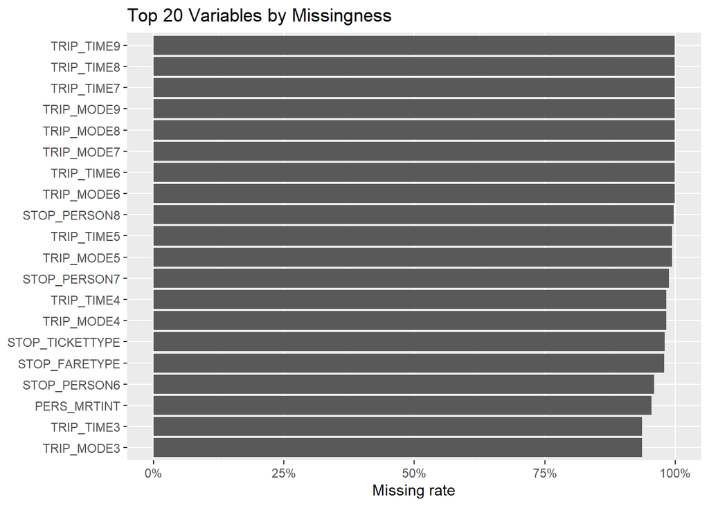

```r
missing_table
```

**Vehicle and Trip Variable Imputation**

Variables with moderate missingness (5–30%) require tailored imputation to preserve information. We identified two groups:

- Vehicle-related variables (~18.6% missing: `STOP_VEHOCCUP`, `STOP_VEHONORANGEFORM`, `STOP_VEHNUM`, `STOP_VEHWALKTIME`). Missingness reflects non-vehicle trips rather than random gaps. We impute categorical variables as “No Vehicle”, numeric as 0, and `STOP_VEHWALKTIME` with the median of positive values (since it only applies to parked vehicles). This retains the distinction between motorized and non-motorized trips.
- Trip timing variables (e.g., `TRIP_DURATION` 28.1%, `STOP_DEPHR` 25.9%). Missingness likely comes from incomplete diaries or recall errors. For durations, we first reconstruct logically (e.g., `TRIP_DURATION` = `TRIP_TRAVTIME` + `TRIP_WAITTIME`), then use medians to avoid extremes. For departure times, we back-calculate from arrivals where possible, otherwise imputing the modal hour to preserve observed patterns.

**Near-Complete Column Processing**

For variables with <0.1% missingness, we chose deletion over imputation to maintain data integrity. These near-complete columns may include location variables, IDs, timestamps, or other critical fields where even minor imputation could introduce bias. Given the minimal sample loss (<20 rows), deletion has negligible impact on analysis power while ensuring data authenticity.

**Remaining Missing Values**

After the above treatments, some variables still contain missing values (`PERS_ADDITIONALTRAVEL` and `PERS_CYCLEDSCHOOL`). Following our minimal intervention principle, these are left unimputed for this cleaning phase, allowing informed imputation decisions during modeling based on their relationships with the target variable.

#### 3.2 Data Validity Checks

Survey data often contains special codes that should not be treated as actual values. In our dataset, negative values were found primarily in: - Time variables (e.g., `STOP_TRAVTIME`, `TRIP_ARRTIME`) where -1 likely indicates “not recorded” - Count variables (e.g., `STOP_VEHNUM`) where negative values are logically impossible - ID fields where negative values suggest special cases or errors

#### 3.3 Type Conversion

Following the principle of minimal intervention for data cleaning, we only corrected obvious type errors where numeric data was stored as text. This focused on vehicle attributes (year, age) and measurement variables (time, distance, weight) that are clearly quantitative in nature.

#### 3.4 Duplicate and Technical Column Removal

`STOPID` serves as the unique row identifier, with `PERSID` and `TRIPID` retained for grouping analyses. After verifying `STOPID` uniqueness, we checked for rows that were identical except for `STOPID` (potential data entry errors) and removed any exact duplicates.

#### 3.5 Outlier Treatment

IQR-based capping was applied to prevent extreme values from dominating model estimation. However, variables with natural long-tail distributions (distance, time, cost) were excluded from this treatment as their extremes represent valid observations (e.g., long-distance trips).

The final cleaned dataset contains **22,583 rows × 163 columns**, ready for travel mode choice analysis.

### 4 Explore and Visualize

#### 4.1 Explore the relationship between independent variables and dependent variables

The following two figures use η² (eta-squared) to visualize the correlation between numerical features and categorical targets, and the other uses Cramér’s V to visualize the correlation between categorical features and categorical targets.The higher the η² or Cramér’s V, the stronger the correlation between the feature and the target (dependent variable).

**Figure1**

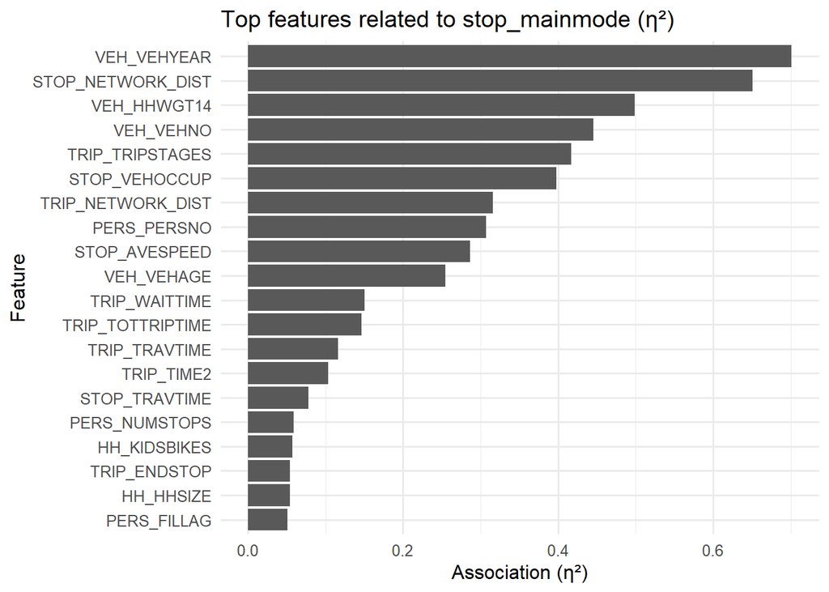

```r
eta_plot
```

As can be seen from the figure above, the five features `VEH_VEHYEAR`, `STOP_NETWORK_DIST`, `VEH_HHWGT14`, `VEHVEHNO`, and `TRIP_TRIP_TRIPSTAGES` have the strongest correlation with the dependent variable `STOP_MAINMODE` and may be used as relatively good features for prediction. However, it may be necessary to focus on reviewing the two features “VEH_VEHYEAR” and “STOP_NETWORK_DIST” with too high η² to confirm whether they are process/posterior variables and consider removing them to avoid the model making incorrect decisions in subsequent training.

**Figure2**

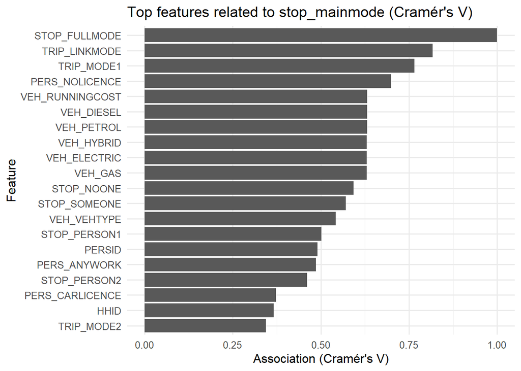

```r
cramers_plot
```

As shown in the figure above, since the Cramér’s V for “STOP_FULLMODE” is 1 (or very close to 1), it can be determined to be a leaky/synonymous field and must be removed. “TRIP_LINKMODE” and “TRIP_MODE1” are also likely leaky/synonymous fields and may be considered for removal to avoid negatively impacting subsequent model predictions. The Cramér’s V for the features “PERS_NOLICENCE”, “VEH_RUNNINGCOST”, “VEH_DIESEL”, “VEH_PETROL”, and “VEH_HYBRID” are all high and within a reasonable range, indicating a high correlation with the dependent variable. They may be suitable as excellent features for prediction and for training a more accurate model.

#### 4.2 Exploring collinearity between features

The Pearson correlation coefficient was calculated and |r| was taken. Hierarchical clustering was performed, defining the distance as 1-|r|. This yielded a cluster structure that reflected collinearity between variables. Clusters formed at |r| >= 0.8 (1-|r| <= 0.2) were defined as groups of variables with highly overlapping information.

**Figure**

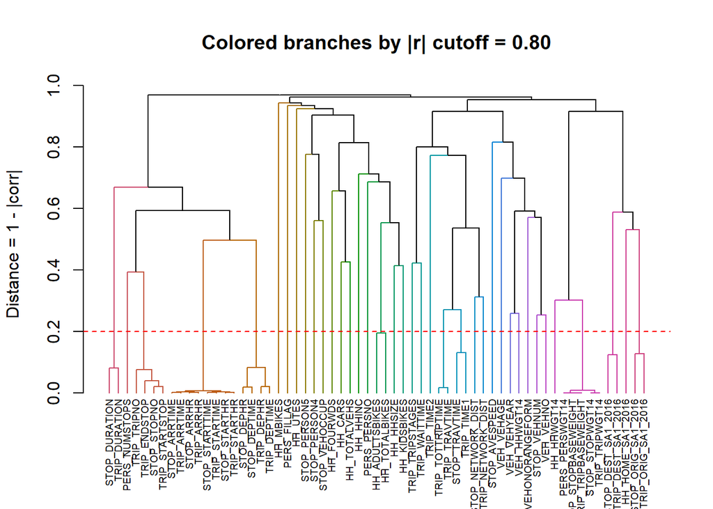

```r
plot_dendrogram()
```

#### 4.3 Exploring class imbalance for STOP_MAINMODE (target/dependent variable)

This example shows the number of samples and their proportion for each class in `STOP_MAINMODE`. The rare class (p < 2%) is marked in red.

**Figure1**

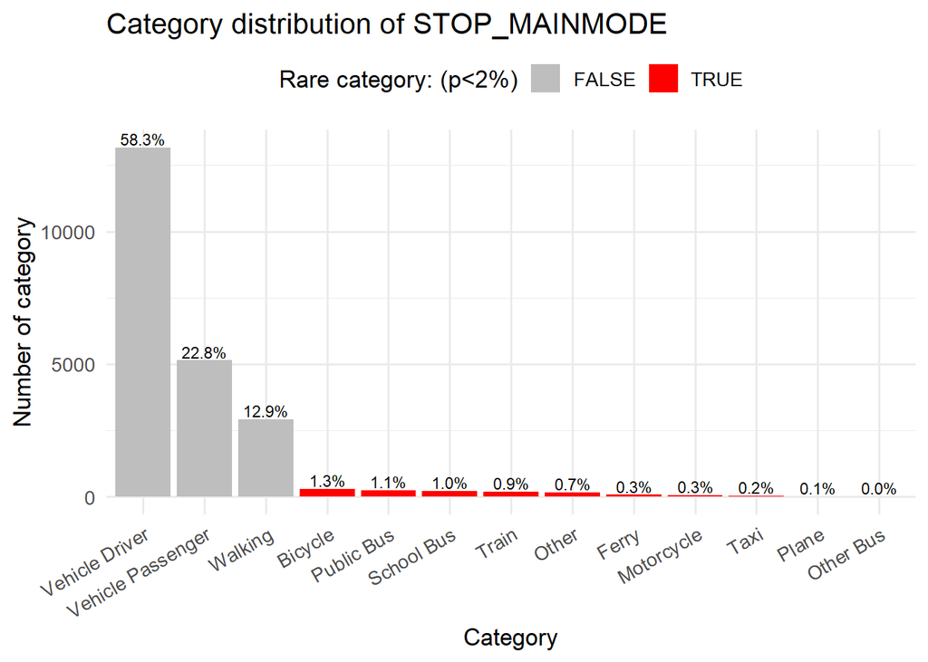

```r
dist_table
```

**Figure2**

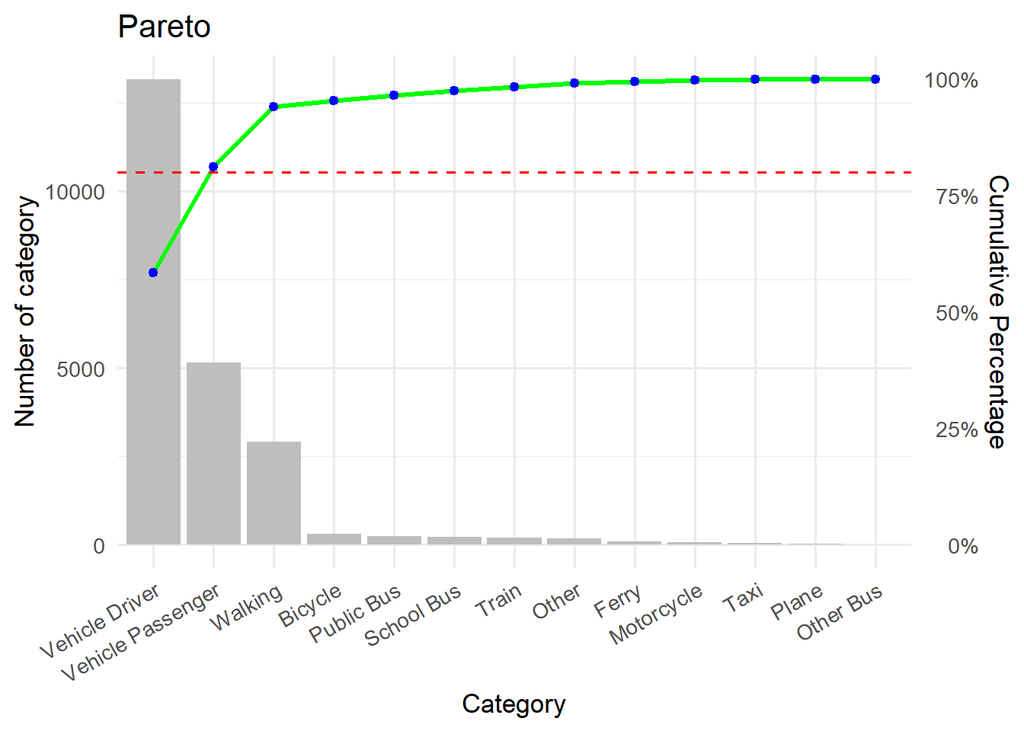

```r
# Diagram2：Pareto
max_n <- max(dist_tbl$n)
ggplot(dist_tbl, aes(x = reorder(class, -n))) +
  geom_col(aes(y = n), fill = "grey") +
  geom_line(aes(y = cum_p * max_n, group = 1), linewidth = 1.1, color = "green") +
  geom_point(aes(y = cum_p * max_n), color = "blue") +
  geom_hline(yintercept = 0.8 * max_n, linetype = 2, color = "red") +
  scale_y_continuous(
    name = "Number of category",
    sec.axis = sec_axis(~ . / max_n, name = "Cumulative Percentage", labels = percent_format(accuracy = 1))
  ) +
  labs(title = "Pareto", x = "Category") +
  theme_minimal(base_size = 13) +
  theme(axis.text.x = element_text(angle = 30, hjust = 1))
```

The two figures indicate that the target `STOP_MAINMODE` shows a typical long-tail class distribution. The tail classes have very few samples, which can lead to unidentifiable parameters, large variance, and unstable evaluation metrics. In downstream modeling, the first two classes (“Vehicle Driver” and “Vehicle Passenger”) together cover over 80% of all samples, so using stratified splits/cross-validation is essential; otherwise, some folds may contain no instances of certain classes. If you keep the full multiclass setting including the tail classes, consider resampling, class weighting, or focal loss; alternatively, adopt a hierarchical/two-stage approach: first “major classes vs. other”, then subdivide the “other” group

### 5 Plan for Evaluation

Overall accuracy is first reported as a baseline, but special attention is given to **macro-averaged precision**, **recall**, and **F1-score**. These metrics assign equal weight to each class, ensuring that minority modes such as cycling and walking are not overshadowed by dominant categories like private vehicles.

**Precision** measures how many of the samples the model predicts as a particular mode of travel actually belong to that mode. For example, if the model labels 100 trips as cycling and 80 are correct, the precision for cycling is 80%.

**Recall** measures how many of the real-world samples of a particular mode of travel are correctly identified by the model. If 60 of 100 true cycling trips are predicted correctly, the recall is 60%.

**The F1 score**, the harmonic mean of precision and recall, provides a balanced measure of predictive accuracy and coverage, particularly valuable when classes are imbalanced.

To complement these summary statistics, a confusion matrix will be used to visualize misclassification patterns, highlighting, for instance, whether walking trips are frequently misclassified as cycling. Such insights not only identify weaknesses in model performance but also provide interpretable guidance for transport policy.

Finally, to enhance the robustness and generalizability of the model results, this study will employ k-fold cross-validation. This method partitions the dataset into k subsets, selecting one of them as the test set and the remaining as the training set. The results are averaged after repeated iterations. This method reduces the random influence of a single partitioning, allowing for a more objective evaluation of the model’s performance under different data partitions.

Through this combination of metrics, visualization, and validation, this study was able to conduct a comprehensive, detailed, and rigorous evaluation of the model’s predictive performance.

### 6 Choice of Classification Models

Model selection balances interpretability and predictive performance, combining statistical and machine learning approaches appropriate for a multi-class outcome and heterogeneous predictors.

**Multinominal Logistic Regression**

It is well-suited to handling the multi-categorical nature of the target variable `STOP_MAINMODE`. This model can quantitatively explain the marginal impact of demographic and household characteristics on travel mode choice, for example, whether an increase in vehicle ownership significantly increases the probability of choosing “vehicle.” This interpretability is particularly valuable for policymakers.

**Decision Tree**

Decision trees produce clear, interpretable rules. For example, households with more than four members and two vehicles are more likely to choose private cars, whereas students without vehicle access tend to rely on buses. The method handles categorical predictors such as gender and occupation directly, yielding intuitive and easily communicated conclusions.

**Random Forests**

Random forests extend decision trees by aggregating many trees, thereby improving robustness and predictive accuracy. They also provide feature importance rankings, such as assessing whether vehicle count or occupation is most influential, which directly aligns with the study’s objective of identifying key determinants of travel mode.

**Support Vector Machine (SVM)**

SVM particularly well-suited for processing high-dimensional feature combinations. For example, variables such as age, family size, occupation, and number of vehicles may interact with each other in complex ways. SVMs can exploit these nonlinear boundaries using kernel functions, effectively distinguishing easily confused categories such as walking and cycling.

**Gradient Boosting (such as XGBoost)**

Achieves strong predictive accuracy in multi-class settings by iteratively refining misclassified cases. Particularly suited to capturing subtle interactions across household and trip variables, while also providing feature importance.

### 7 Our Innovation

The innovations of this study are reflected in three dimensions.

Data: It draws on household travel survey data from Gold Coast residents, incorporating demographic and household variables such as age, gender, occupation, household size, and vehicle ownership. These features provide an authentic representation of local travel behaviour and are highly relevant to sustainable transport planning.

Methods: The analysis integrates traditional statistical models (logistic regression, decision trees) with machine learning approaches (random forests, support vector machines, gradient boosting). This combined framework enables both interpretation of variable effects and improved predictive accuracy.

Results: Findings are communicated through visual tools, including confusion matrices, feature importance rankings and model comparison plots, which enhancing interpretability and accessibility for policymakers.

Overall, by combining regional data, diverse modelling strategies, and clear presentation, the study offers both academic contributions and practical insights for transport planning.